# Text Mining en Don Quijote de La Mancha

by [Juan Manuel Ortiz](https://www.linkedin.com/in/juan-manuel-ortiz-10956a80/)

5/7/2020

## Analisis del libro Don Quijote de La Mancha

Vamos a intentar hacer un análisis del libro, intentando encontrar las palabras más frecuentes, así como las palabras que más relación tienen entre ellas. Usaremos distintos métodos para mostrarlo en forma de tablas o de una manera más gráfica.

### 1. Instalación de paquetes/Carga de librerias

```r
if(!is.element("tidyverse", installed.packages()[, 1]))
      install.packages("tidyverse", repos = 'http://cran.us.r-project.org')
library(tidyverse)
if(!is.element("(gutenbergr", installed.packages()[, 1]))
      devtools::install_github("ropenscilabs/gutenbergr")
library(gutenbergr)
if(!is.element("tidytext", installed.packages()[, 1]))
      install.packages("tidytext", repos = 'http://cran.us.r-project.org')
library(tidytext)
if(!is.element("drlib", installed.packages()[, 1]))
      devtools::install_github("dgrtwo/drlib")
library(drlib)
if(!is.element("quanteda", installed.packages()[, 1]))
      install.packages("quanteda", repos = 'http://cran.us.r-project.org')
library(quanteda)
if(!is.element("stm", installed.packages()[, 1]))
      install.packages("stm", repos = 'http://cran.us.r-project.org')
library(stm)
library(readr)
library(tm)
library(wordcloud)
library(stats)
library(udpipe)
library(lattice)
library(ggraph)
library(igraph)
library(textrank)
library(wordcloud)
library(stringi)
```

### 2. Extracción de los datos

```r
# Extraemos el libro Don Quijote de la Mancha desde el proyecto Gutenberg usando su número de libro, en este caso el 2000

quijote_raw <- gutenberg_download(2000)
```

```
## Determining mirror for Project Gutenberg from http://www.gutenberg.org/robot/harvest
```

```
## Using mirror http://aleph.gutenberg.org
```

```r
# Comprobamos la codificación del libro, en este caso resulta ser ASCII por lo que procedemos a codificarlo a latin1 para que se muestren bien los acentos o caracteres especiales.
guess_encoding(quijote_raw)
```

```
## # A tibble: 1 x 2
##   encoding confidence
##   <chr>         <dbl>
## 1 ASCII             1
```

```r
Encoding(quijote_raw$text) <- "latin1"
guess_encoding(quijote_raw$text)
```

```
## # A tibble: 2 x 2
##   encoding   confidence
##   <chr>           <dbl>
## 1 ISO-8859-1       0.82
## 2 ISO-8859-2       0.37
```

```r
qraw <- quijote_raw$text
```

### 3. Creación de párrafos

Creamos parrafos agrupando lineas de 10 en 10 para reducir las dimensiones y poderlo tratar mejor y que no le pese tanto a nuestro PC.

```r
diez <- rep(1:ceiling(length(qraw)/10), each = 10)
diez <- diez[1:length(qraw)]
qtext <- cbind(diez, qraw) %>% data.frame()
qtext <- aggregate(formula = qraw ~ diez,
                      data = qtext,
                      FUN = paste,
                      collapse = " ")

qtext <- qtext %>% select(qraw) %>% as.matrix

dim(qtext)
```

```
## [1] 3746    1
```

```r
#Se crea una matriz de dimensión 3746 x 1, lo que nos hará más manejable el texto
```

### 4. Creación de Corpus y primera limpieza

```r
# Vamos a crear un corpus

# Eliminamos caracteres que puedan dar conflictos invalid input in 'utf8towcs'
usableText = str_replace_all(qtext,"[^[:graph:]]", " ")

# Quitamos preposiciones
usableText <- removeWords(usableText, words = c('a', 'ante', 'bajo', 'cabe', 'con', 'contra', 'de', 'desde', 'durante', 'en', 'entre', 'hacia', 'hasta', 'mediante', 'para', 'por', 'según', 'sin', 'so', 'sobre', 'tras', 'vía'))

# Quitamos adverbios
usableText <- removeWords(usableText, words = c('ayer', 'hoy', 'mañana', 'siempre', 'nunca', 'luego', 'ya', 'ahora', 'frecuentemente', 'antes', 'aquí', 'ahí', 'allí', 'allá', 'acá', 'cerca', 'lejos', 'arriba', 'abajo', 'delante', 'detrás', 'enfrente', 'encima', 'debajo', 'donde', 'así', 'bien', 'mal', 'cuidadosamente', 'mejor', 'peor', 'como', 'mucho', 'poco', 'más', 'menos', 'bastante', 'nada', 'cuanto', 'sí', 'claro', 'bueno', 'obviamente', 'también', 'no', 'tampoco', 'nada', 'apenas', 'jamás', 'nunca', 'quizá', 'probablemente', 'seguramente', 'acaso', 'demás','inclusive','aún'))

# Quitamos acentos
acentos.text <- function(x){
  # Quito todos los acento para tener menos dificultades con la nube de palabras
  # Cambio la ñ porque de problemas en la nube
  x <- gsub("á", "a", x)
  x <- gsub("é", "e", x)
  x <- gsub("í", "i", x)
  x <- gsub("ó", "o", x)
  x <- gsub("ú", "u", x)
  x <- gsub("ñ", "n", x)
}

# Aplicamos la función
usableText <- acentos.text(usableText)

# Creamos corpus
quijote_corpus1 <- Corpus(VectorSource(usableText))

# Miramos los primeros 5 párrafos
inspect(quijote_corpus1[1:5])
```

```
## <<SimpleCorpus>>
## Metadata:  corpus specific: 1, document level (indexed): 0
## Content:  documents: 5
##
## [1] El ingenioso hidalgo don Quijote  la Mancha   TASA  Yo, Juan Gallo  Andrada, escribano  Camara del Rey nuestro senor,  los que residen  su Consejo, certifico y doy fe que, habiendo visto  los senores del un libro intitulado El ingenioso hidalgo  la Mancha, compuesto  Miguel  Cervantes Saavedr…
## [2] el acatamiento que debo  tanta grandeza, suplico le reciba agradablemente  su proteccion,  que  su sombra, aunque desnudo  aquel precioso ornamento  elegancia y erudicion  que suelen andar vestidas las obras que se componen  las casas  los hombres que saben, ose parecer   el juicio  algunos q…
## [3] El ventero, que,  esta dicho, era un  socarron y  tenia algunos barruntos  la falta  juicio  su huesped, acabo  creerlo cuando acabo  oirle semejantes razones, y,  tener que reir aquella noche, determino  seguirle el humor; y , le dijo que andaba muy acertado  lo que deseaba y pedia, y que ta…
## [4]  -¿Por que lo dices, Sancho? -dijo don Quijote.  -Digolo -respondio- porque estos palos  agora  fueron  la pendencia que  los dos trabo el diablo la otra noche, que  lo que dije  mi senora Dulcinea,  quien amo y reverencio   una reliquia, aunque  ella  lo haya, solo  ser cosa  vuestra merced.…
## [5]  pecado nuevo, penitencia nueva.  En tanto que los dos iban  estas platicas, dijo el cura  Dorotea que habia andado muy discreta,   el cuento   la brevedad del, y  la similitud que tuvo  los  los libros  caballerias. Ella dijo que muchos ratos se habia entretenido  leellos, pero que  sabia el…
```

Se aprecia como los párrafos se han creado. Pero todavía es necesaria una limpieza mayor del texto

#### 4.1 Segunda limpieza del texto

```r
# Pasar a minúsculas
corpus_clean <- tm_map(quijote_corpus1, tolower)
# Quitar números
corpus_clean <- tm_map(corpus_clean, removeNumbers)
# Quitamos signos de puntuacion
corpus_clean <- tm_map(corpus_clean, removePunctuation)
# Quitamos las stopwords
corpus_clean <- tm_map(corpus_clean, removeWords, stopwords(kind = 'es'))
# Quitamos espacio en blanco
corpus_clean <- tm_map(corpus_clean, stripWhitespace)
# Vemos los primeros 10 parrafos
inspect(corpus_clean[1:10])
```

```
## <<SimpleCorpus>>
## Metadata:  corpus specific: 1, document level (indexed): 0
## Content:  documents: 10
##
##  [1]  ingenioso hidalgo don quijote mancha tasa juan gallo andrada escribano camara rey senor residen consejo certifico doy fe visto senores libro intitulado ingenioso hidalgo mancha compuesto miguel cervantes saavedra tasaron cada pliego dicho libro tres maravedis medio ochenta tres pliegos
##  [2]  acatamiento debo tanta grandeza suplico reciba agradablemente proteccion sombra aunque desnudo aquel precioso ornamento elegancia erudicion suelen andar vestidas obras componen casas hombres saben ose parecer juicio continiendose limites ignorancia suelen condenar rigor justicia trabajos aj…
##  [3]  ventero dicho socarron tenia barruntos falta juicio huesped acabo creerlo acabo oirle semejantes razones tener reir aquella noche determino seguirle humor dijo andaba acertado deseaba pedia tal prosupuesto propio natural caballeros tan principales parecia gallarda presencia mostraba ansimes…
##  [4]  ¿ dices sancho dijo don quijote digolo respondio palos agora pendencia dos trabo diablo noche dije senora dulcinea amo reverencio reliquia aunque solo ser cosa merced tornes platicas sancho vida dijo don quijote dan pesadumbre perdone entonces sabes suele decirse
##  [5]  pecado nuevo penitencia nueva dos iban platicas dijo cura dorotea habia andado discreta cuento brevedad similitud libros caballerias dijo ratos habia entretenido leellos sabia provincias puertos mar habia dicho tiento habia desembarcado osuna entendi dijo cura acudi decir
##  [6] dije acomodo ¿ cosa estrana ver cuanta facilidad cree desventurado hidalgo todas invenciones mentiras solo llevan estilo modo necedades libros si dijo cardenio tan rara vista si queriendo inventarla fabricarla mentirosamente tan agudo ingenio pudiera dar pues cosa ello dijo cura simplicidade…
##  [7]  buen hidalgo dice tocantes locura si tratan cosas discurre bonisimas razones muestra tener entendimiento apacible manera toquen caballerias habra nadie juzgue sino buen entendimiento iban conversacion prosiguio don quijote dijo sancho echemos panza amigo pelillos mar pendencias
##  [8] dime tener cuenta enojo rencor alguno ¿ hallaste dulcinea ¿ hacia ¿ dijiste ¿ respondio ¿ rostro hizo leia carta ¿ traslado aquello vieres caso digno saberse preguntarse satisfacerse anadas mientas darme gusto acortes quitarmele senor respondio sancho si va decir verdad carta traslado nadie …
##  [9] asi dices dijo don quijote librillo memoria escribi halle poder cabo dos dias partida causo grandisima pena saber habias hacer vieses carta crei volvieras lugar echaras asi respondio sancho si tomado memoria merced leyo manera dije sacristan traslado entendimiento tan punto punto dijo dias v…
## [10]  habia visto leido tan linda carta aquella ¿tienesla todavia memoria sancho dijo don quijote senor respondio sancho despues di vi habia ser provecho di olvidalla si acuerda aquello sobajada digo soberana senora ultimo muerte caballero triste figura medio destas dos cosas puse trecientas alma…
```

### 5. Nube de palabras / Wordcloud

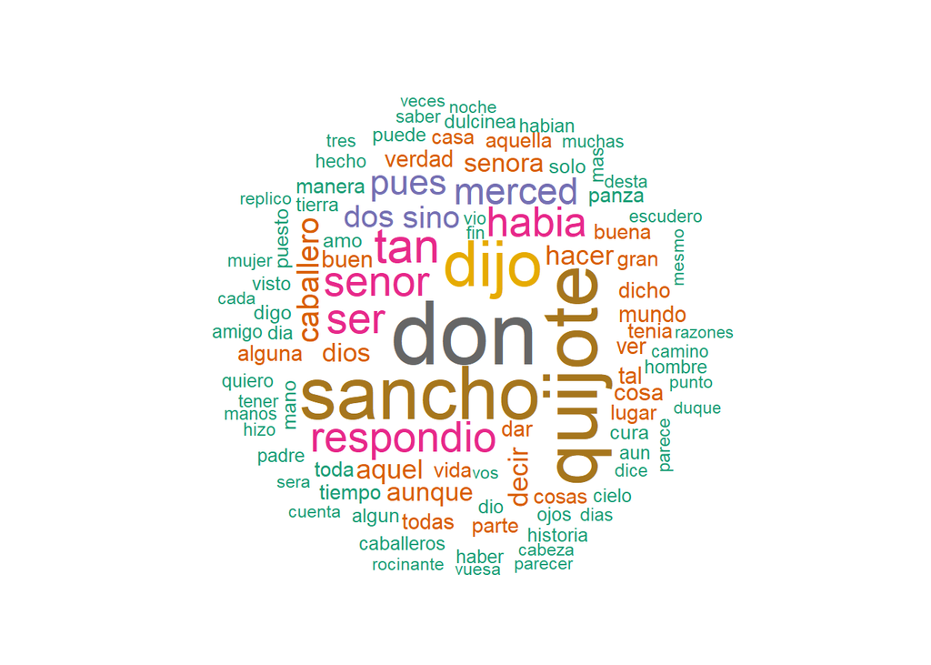

```r
#Nube de palabras

# Nos quedamos con las palabras que aparecen, al menos 200 veces
wordcloud(corpus_clean, min.freq = 200, random.order = FALSE, colors = brewer.pal(name = "Dark2", n = 8))
```

### 6. Primeros análisis usando DTM / TDM

```r
# Creamos un dtm
quijote_dtm <- DocumentTermMatrix(corpus_clean)

# Creamos un tdm
quijote_tdm <- TermDocumentMatrix(corpus_clean)

# Palabras frecuentes
quijote_mat <- as.matrix(quijote_tdm)
dim(quijote_mat)
```

```
## [1] 22619  3746
```

```r
# Vemos la dimensión de la nueva matriz creada
```

```r
# Usamos2 maneras distintas de mostrar la frecuencia
# La primera:
quijote_mat <- quijote_mat %>% rowSums() %>% sort(decreasing = TRUE)
quijote_mat <- data.frame(palabra = names(quijote_mat), frec = quijote_mat)
quijote_mat[1:20, ]
```

```
##             palabra frec
## don             don 2647
## quijote     quijote 2175
## sancho       sancho 2148
## dijo           dijo 1807
## tan             tan 1233
## senor         senor 1062
## respondio respondio 1062
## ser             ser 1056
## habia         habia 1030
## merced       merced  899
## pues           pues  855
## sino           sino  694
## dos             dos  683
## caballero caballero  661
## decir         decir  578
## hacer         hacer  535
## aquel         aquel  533
## aunque       aunque  530
## dios           dios  524
## senora       senora  514
```

```r
# La segunda, con palabras frecuentes:
findFreqTerms(quijote_dtm, 500)
```

```
##  [1] "don"       "quijote"   "senor"     "aquel"     "aunque"    "tan"
##  [7] "dijo"      "habia"     "dos"       "merced"    "respondio" "sancho"
## [13] "senora"    "ser"       "decir"     "pues"      "sino"      "hacer"
## [19] "caballero" "dios"
```

#### 6.1 Mostramos de manera gráfica los resultados

Primero mostramos las palabras más repetidas

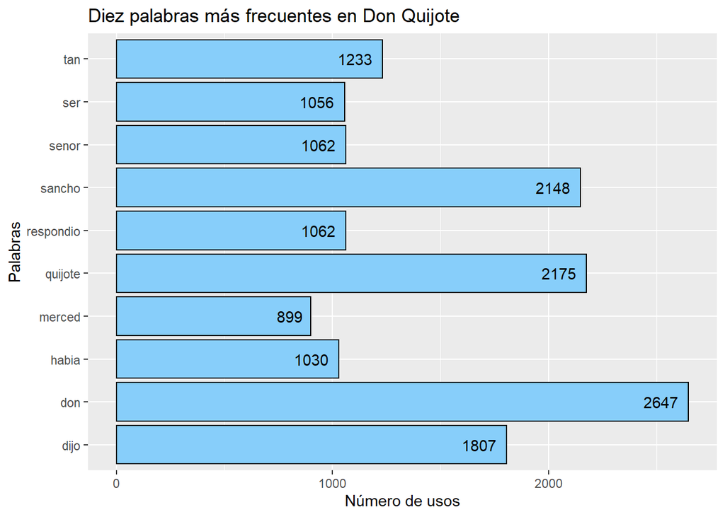

```r
#IMPLEMENTAR GRAFICAS

quijote_mat[1:10, ] %>%
  ggplot(aes(palabra, frec)) +
  geom_bar(stat = "identity", color = "black", fill = "#87CEFA") +
  geom_text(aes(hjust = 1.3, label = frec)) +
  coord_flip() +
  labs(title = "Diez palabras más frecuentes en Don Quijote",  x = "Palabras", y = "Número de usos")
```

Segundo mostramos la proporción de uso de esas 10 palabras en todo nuestro documento

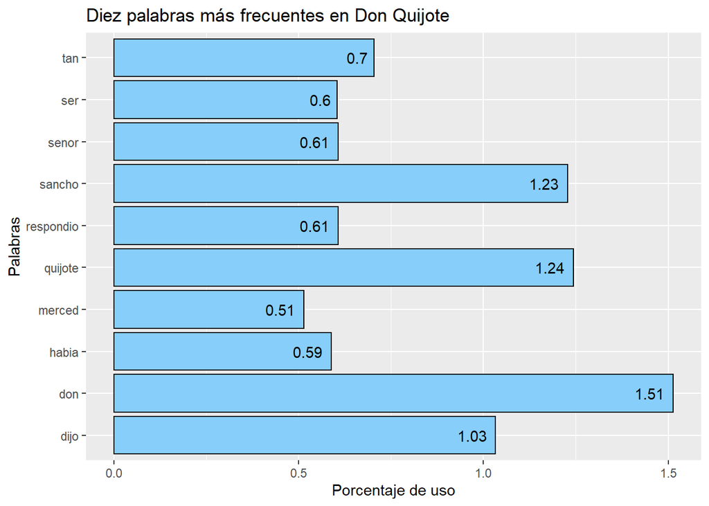

```r
quijote_mat %>%
  mutate(perc = (frec/sum(frec))*100) %>%
  .[1:10, ] %>%
  ggplot(aes(palabra, perc)) +
  geom_bar(stat = "identity", color = "black", fill = "#87CEFA") +
  geom_text(aes(hjust = 1.3, label = round(perc, 2))) +
  coord_flip() +
  labs(title = "Diez palabras más frecuentes en Don Quijote", x = "Palabras", y = "Porcentaje de uso")
```